## Realizar validação de banco de dados

As ferramentas de validação atualmente disponíveis são capazes de identificar e resolver diversos problemas geométricos que ocorrem no processo de produção de geoinformação vetorial. Essas ferramentas são um primeiro passo na garantia da qualidade geométrica. Elas podem ser acessadas pelo menu principal ou pelo botão .Nos itens seguintes será mostrado o objetivo de cada ferramenta e como usá-las.

### Visão geral

O primeiro passo para usar as ferramentas de validação é selecionar o banco de dados EDGV que se deseja validar geometricamente. Isso se faz clicando no botão "Abrir" como se pode ver na figura 55.

*Figura 55: Escolhendo um banco*

Com a seleção do banco de dados desejado é possível ver a lista de processos disponíveis. Atualmente existem 20 processos disponíveis. Na próxima seção serão analisados, em detalhes, cada um desses processos.

### Processos disponíveis

Todos os processos funcionam em todas as camadas existente no banco de dados selecionado. Existem processos de identificação de erros e processos de correção de erros.

Os processos de identificação apenas levantam *flags* (erros marcados para posterior análise do operador) enquanto que os processos de correção executam modificações nas camadas, deixando-as em modo edição para posterior análise do operador. Caso tudo esteja conforme o esperado, o operador pode salvar as modificações e prosseguir com a validação.

A figura seguinte mostra os processos disponíveis e o botão para rodar os processos em destaque.

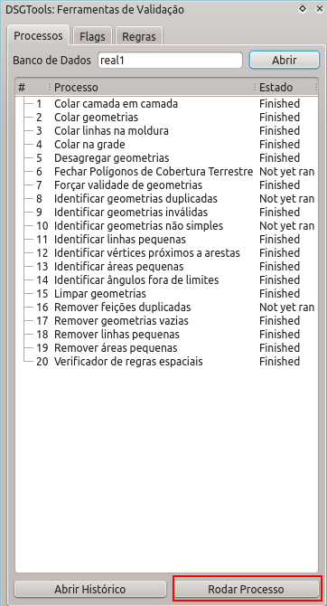

*Figura 56: Processos disponíveis*

Todos os processos necessitam de parâmetros para serem executados, eles são diferentes de acordo com cada processo a menos da seleção de classes. Os processos podem ser rodados em apenas um conjunto de classes, permitindo ao usuário do DSGTools mais rapidez na correção de problemas específicos de uma dada classe.

#### *Colar camada em camada*

Este processo atrai uma camada para outra camada, ou seja, funciona entre camadas. Este processo é util para garantir a resolução de problemas de sobreposição e vazios (*gaps*) entre as camadas selecionadas. O processo necessita que uma classe seja determinada como referência, desta forma todas as feições da outra classe serão atraídas para a referência. A figura abaixo mostra problemas de vazio entre camadas.

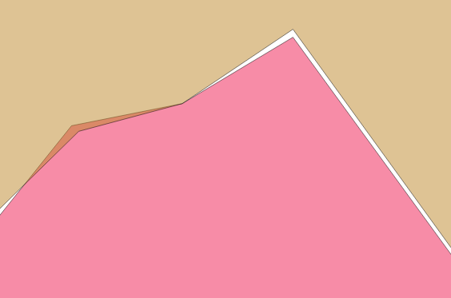

*Figura 57: Problemas de gap e sobreposição*

Para resolver este problema o processo será rodado com os parãmetros presentes na figura abaixo.

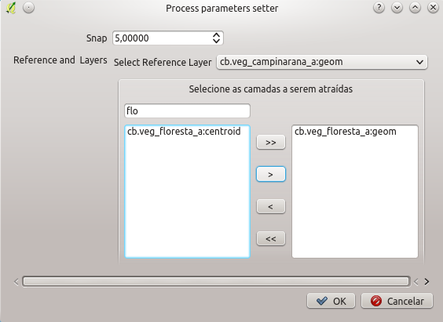

*Figura 58: Parâmetros do processo*

O resultado pode ser visto na figura abaixo.

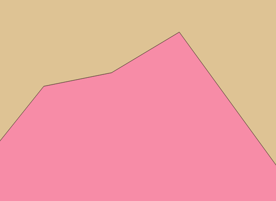

*Figura 59: Problema resolvido*

#### *Colar geometrias*

Processo que usa o GRASS de forma semelhante ao "Limpar geometrias", porém ele apenas executa o snap. Este processo funciona dentro de uma camada e não entre camadas. Na figura abaixo podemos ver uma geometria com erro de aquisição.

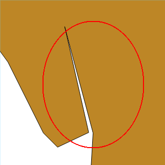

*Figura 60: Geometria com erro*

Após rodar o processo o resultado é o seguinte com os parâmetros da figura 61 temos o resultado apresentado na figura 62.

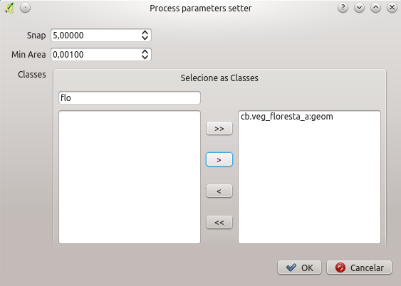

*Figura 61: Parâmetros do processo*

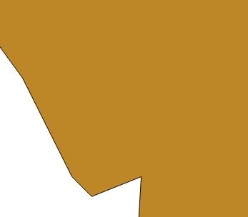

*Figura 62: Geometria após o Colar (Snap)*

#### Colar linhas na moldura

O processo de colar linhas na moldura prolonga linhas e faz o snap das mesmas para a moldura do produto. O processo densifica a moldura criando novos vértices nela que são usados no processo de fechamento de áreas usado no processo "Fechar polígonos de Cobertura Terrestre". Da mesma forma como o processo de identificação de linhas pequenas é necessário que o operador informe a tolerância para o processo e as classes que serão processadas no diálogo mostrado abaixo.

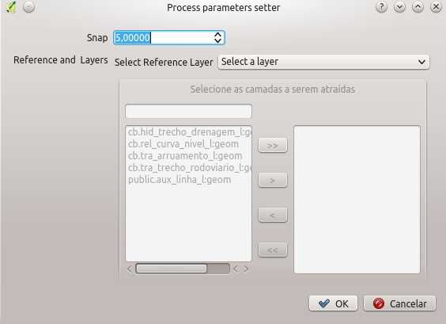

*Figura 63: Parâmetros do processo*

O funcionamento do processo trabalha em situações como a presente na figura 64.

[figure not shown]

Gerando o resultado presente na figura 65.

[figure not shown]

#### Colar na grade

Este processo funciona com o uso da função ST_SnapToGrid do PostGIS, que cola todos os pontos da geometria num grid regular. O objetivo desta ferramenta é ajustar a precisão das coordenadas. Ele é essencial para que os processamentos topológicos corretamente, para garantir que, por exemplo, duas geometrias se toquem de fato.

Sem o uso desse processo, mesmo que duas geometrias teoricamente se toquem (por terem sido adquiridas com o snap do QGIS ligado), não é possível obter o resultado esperado de uma relação de "toca" por exemplo.

Resumindo, esse processo deve ser rodado para, por exemplo, transformar uma coordenada com 17 casas decimais para uma coordenada com apenas 3 casa decimais (ficando limitada aos milímetros, o que é suficiente).

Os parâmetros desse processo são os presentes na figura abaixo.

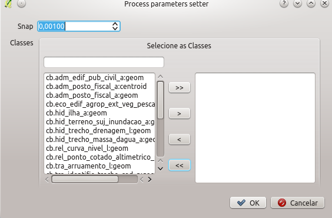

*Figura 66: Parâmetros do processo*

#### Desagregar geometrias

Esse processo separa multigeometrias facilitando o processamento das mesmas pelo banco de dados. Ou seja, caso se tenha um arquipélago com um único ID no banco de dados, eles serão separados criando um ID para cada ilha componente do arquipélago.

#### Fechar polígonos de Cobertura Terrestre

Para este processo funcionar é necessário que já haja uma configuração de cobertura terrestra já existente para o banco de dados selecionado. O processo de configuração de cobertura terrestre pode ser visto em Cobertura Terrestre.

O processo funciona realizando a criação de polígonos delimitados por feições lineares conforme estipulado na configuração de cobertura terrestre. Para cada área criada é feita a verificação da existência ou não de centróides (feições pontuais que contém os atributos da área delimitada). Caso haja apenas um centróide todos os atributos são copiados para a classe correspondente, finalizando a criação do polígono componente da cobertura terrestre. Caso não haja centróide ou haja centróides conflitantes em uma mesma área há a criação de flags para posterior intervenção do operador.

A figura 67 mostra um exemplo de uso da ferramenta.

[figure not shown]

#### Forçar validade de geometrias

Esse processo funciona com o uso da função ST_MakeValid do PostGIS. Ele roda em todas as feições levantadas pelo processo "Identificar geometrias inválidas". A figura 68 mostra o antes e depois do processo para um caso de auto interseção.

[figure not shown]

#### Identificar geometrias duplicadas

Processo que identifica geometrias repetidas no banco de dados. Para cada geometria duplicada é levantada uma flag.

#### Identificar geometrias inválidas

Este processo funciona com o uso da função ST_IsValid do PostGIS. Sendo assim, polígonos com auto interseção ou conforme os presentes na figura 69 são inválidos e, portanto, identificados por meio de flags.

[figure not shown]

#### Identificar geometrias não simples

O processo funciona gerando flags para geometrias não simples. O conceito pode ser visto na figura 70 onde os elementos (b) e (d) são não simples e os elementos (a) e (c) são simples.

[figure not shown]

#### Identificar linhas pequenas

Este processo funciona de maneira simples, ele apenas identifica, de acordo com um comprimento limite, linhas pequenas e levanta flags para cada uma delas.

#### Identificador de vértices próximos a arestas

Este processo necessita da entrada de uma tolerância pelo operador para identificar os vértices que são considerados errôneos por estarem muito próximo a arestas. A entrada da tolerância é feita por meio da janela da figura 71 que é mostrada ao operador no momento da execução do processo.

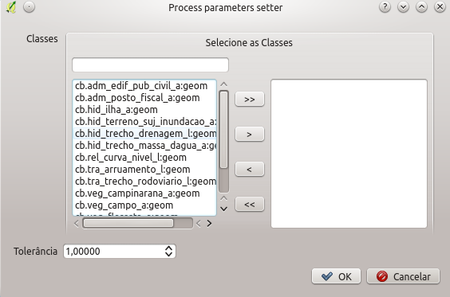

*Figura 71: Parâmetros do processo Vértices próximo a arestas*

O funcionamento pode ser exemplificado com o uso da feição mostrada na figura 72. O vértice em destaque com o quadrado amarelo será identificado e levantado como flag por estar a uma distância menor que a tolerância da aresta presente logo abaixo dele.

[figure not shown]

#### Identificar áreas pequenas

Processo que funciona exatamente como o "Identificar linhas pequenas", porém a tolerância usada é a área mínima a ser usada.

#### Identificar ângulos fora de limites

Este processo funciona identificando vértices de feições do tipo linha e área que formam ângulos fora de um limite pré-estabelecido. Este limite deve ser entrado pelo operador no momento de execução do processo. Na figura 73 pode-se ver a entrada do valor de 10° como limite.

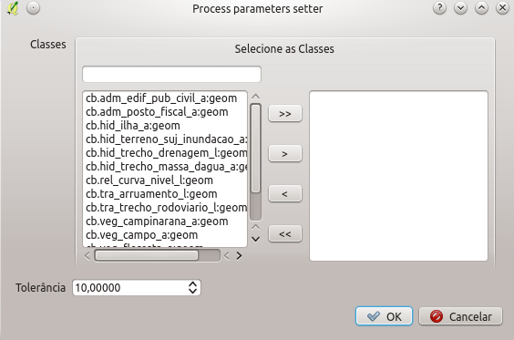

Considere que as feições analisadas são conforme a figura 74.

[figure not shown]

Quando finalizado, o processo levantará flags para posterior intervenção do operador marcando os vértices mostrados na figura 75.

[figure not shown]

#### Limpar geometrias

Este processo funciona com o uso do GRASS, executando os seguintes passos:

- carregamento na estrutura do GRASS com o uso do snap conforme os parêmetros informados pelo operador;
- quebra de linhas/limites em interseções e também quebra de linhas/limites que formam um *loop* colapsado;
- remoção de pequenos ângulos (tão pequenos que são medidos como 0°); e
- remoção de pontas soltas

Resumindo, problemas como os presentes na figura 76 são resolvidos automaticamente gerando os resultados presentes na figura 77.

[figure not shown]

#### Remover feições duplicadas

Processo de remoção que funciona usando as flags levantadas pelo processo "Identificar geometrias duplicadas".

#### Remover geometrias vazias

Este processo é simples, ele funciona removendo feições cuja as geometrias são nulas. Ao término do processo é possível ver em detalhes quantas feições foram removidas abrindo-se o log de mensagens do QGIS.

#### Remover linhas pequenas

Este processo funciona removendo feições a partir das flags levantadas pelo processo "Identificar linhas pequenas".

#### Verificador de regras espaciais

Este processo necessita de uma configuração de regras topológicas para funcionar. Essa definição de regras é feita por meio da aba "Regras" na Caixa de ferramentas de validação. O acesso ao editor de regras é feito por meio do botão "Mostrar editor de regras espaciais". Ao se clicar nesse botão o diálogo presente na figura 78 será mostrado.

[figure not shown]

A edição de regras é bem simples, tudo é feito a partir de seleções nos campos mostrados na figura 79.

[figure not shown]

Ao fim da seleção dos valores de "Camada #1", "Necessidade", "Predicado espacial", "Camada #2" e "Cardinalidade" deve-se clicar em "Inserir Regra" para adicioná-la a lista de regras já existentes. Da mesma forma, é possível remover regras clicando-se em uma já existente e posteriormente clicando em "Remover Regra". Ao término do processo deve-se clicar em "Ok" para salvar a configuração de regras.

Agora resta ao operador rodar o processo para que sejam levantadas flags para cada erro levantado no verificação das regras.

#### Reforçador de Regras Espaciais

O reforçador de regras espaciais roda em tempo real testando as regras de relacionamento topológico para a camada corrente que está em modo edição no QGIS. Este processo funciona como o "Verificador de regras espaciais", porém gera flags em tempo real. O reforçador foi implementado tendo em vista que existe ferramenta semelhante no *Gothic* e, segundo os operadores entrevistados, este processo é muito útil na validação de uma carta.

A ativação do reforçador é feita por meio da aba "Regras" ao clicar-se em "Iniciar/Parar Reforçador de Regras Espaciais" como se pode ver na figura 80.

[figure not shown]

A partir da ativação do reforçador, cada evento de edição na camada executado pelo operador vai disparar os testes topológicos e, caso haja erros, serão levantadas flags.

### Verificando as flags levantadas pelos processos

A aba "Flags" possui a tabela de flags levantada por cada processo de validação para o banco de dados selecionado. Na figura 81 vemos um exemplo de flags levantadas para o processo "Identificador de vértices próximos a arestas"

[figure not shown]

Na tabela de flags é possível ver a classe onde foi levantada a flag, o id da feição que deu origem a flag, a motivo da flag ter sido levantada, uma coluna que futuramente será usada para marcar se a flag já foi corrigida pelo operador e a dimensão da flag (ponto – 0, linha – 1, área – 2).

Para visitar a flag para inspeção do operador basta que seja clicado o botão direito do mouse em uma das flags para ver um menu com a opção "Zoom para a flag" como se pode ver na figura 82. Isso irá carregar a camada de flags e centralizará a visualização do QGIS na flag selecionada exatamente como se pode ver na figura 82.

[figure not shown]

### Histórico de Validação

O histórico permite ao operador verificar todas as execuções de processos de validação informando nome do processo, o log do processo, o estado do processo ao término da execução e a data/hora do processo. O histórico é acessado pelo botão "Abrir Histórico" presenta na aba "Processos". A figura 83 mostra um exemplo de histórico.

[figure not shown]